# River Remedy: Comprehensive Contamination Analysis

Pilcomayo River Basin Heavy Metal Assessment (2006-2024)

Author

River Remedy Team

Published

July 16, 2025

# Executive Summary

**🚨 Critical Findings**

This comprehensive analysis of the Pilcomayo River Basin reveals **catastrophic heavy metal contamination** with:

- **90.4% of samples exceeding WHO standards**
- **Lead contamination up to 231,150x WHO limits**
- **Multiple extreme contamination hotspots identified**
- **Systemic contamination across all environmental matrices**

[output not shown]

# Study Overview

This report analyzes heavy metal contamination across the Pilcomayo River Basin using data from the **2006 ITA Baseline Study**, which sampled 1446 observations across 16 locations in 6 different environmental matrices.

## Sample Distribution

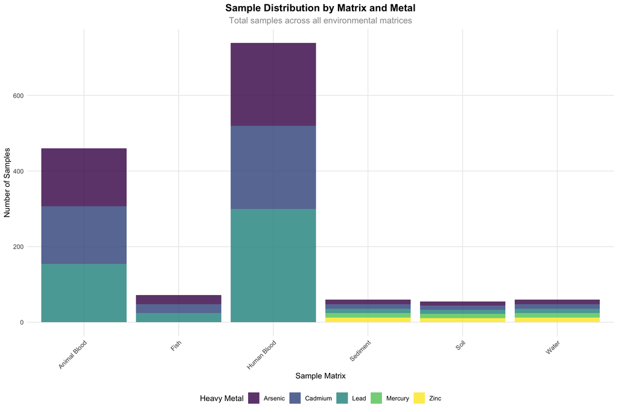

# Contamination Risk Assessment

## Overall Risk Distribution

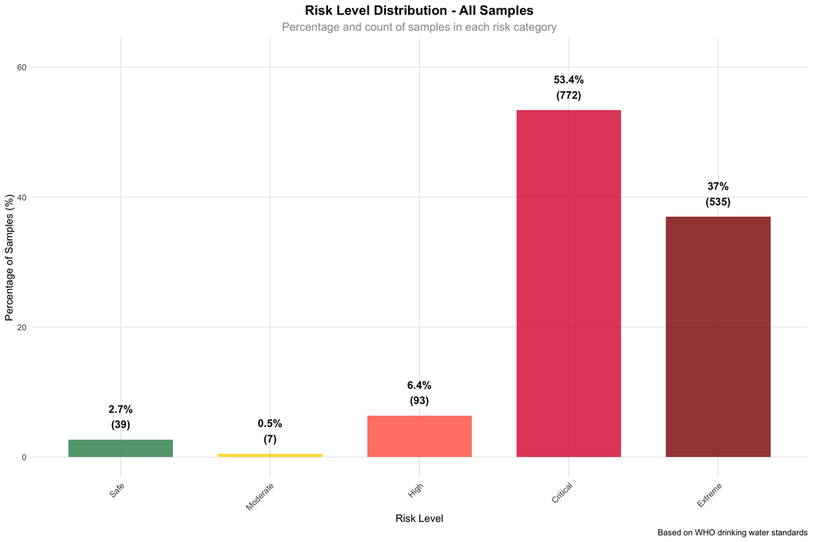

**Key Risk Statistics**

| Risk_Level | Samples | Percentage |
| --- | --- | --- |
| Critical | 772 | 53.4% |
| Extreme | 535 | 37% |
| High | 93 | 6.4% |
| Moderate | 7 | 0.5% |
| Safe | 39 | 2.7% |

## Risk by Sample Matrix

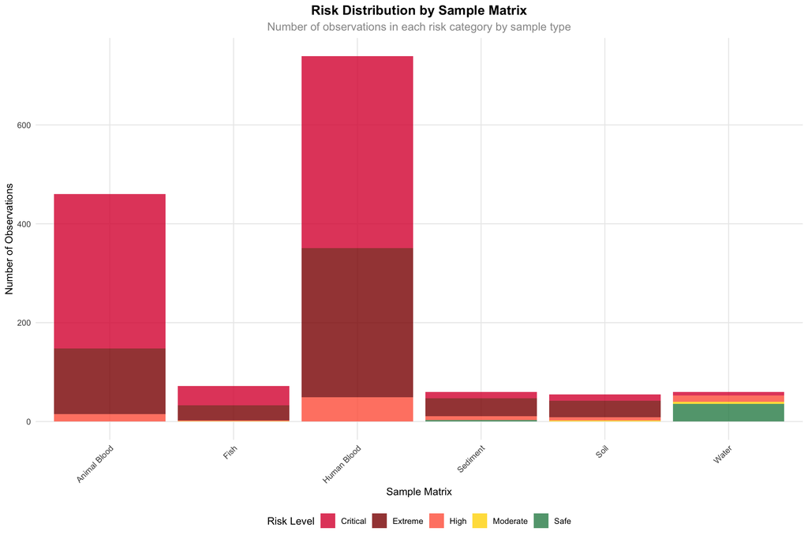

# Lead Contamination Analysis

Lead shows the most severe contamination across all matrices. The following analysis focuses on lead as the priority contaminant.

[figure not shown]

## Lead Contamination by Location

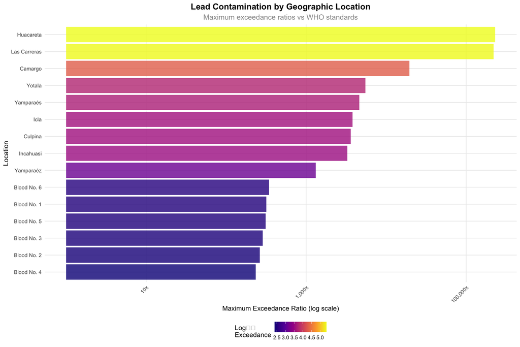

## Critical Contamination Sites

|  | Location | Metal | Sample Type | Concentration (mg/L) | WHO Exceedance | Risk Level |
| --- | --- | --- | --- | --- | --- | --- |
| 1 | Huacareta | Lead | Soil | 2311.5 | 231150 | Extreme |
| 2 | Las Carreras | Lead | Fish | 2207 | 220700 | Extreme |
| 3 | Camargo | Lead | Fish | 195.9 | 19590 | Extreme |
| 4 | Las Carreras | Arsenic | Fish | 104 | 10400 | Extreme |
| 5 | Las Carreras | Lead | Fish | 88.38 | 8838 | Extreme |
| 6 | Camargo | Lead | Soil | 64.92 | 6492 | Extreme |
| 7 | Las Carreras | Lead | Soil | 63.76 | 6376 | Extreme |
| 8 | Las Carreras | Lead | Sediment | 56.4 | 5640 | Extreme |
| 9 | Yotala | Lead | Human Blood | 54.9 | 5490 | Extreme |
| 10 | Yotala | Lead | Human Blood | 48.7 | 4870 | Extreme |

[output cut: 10 more lines]

# Multi-Metal Analysis

## Metal Priority Ranking

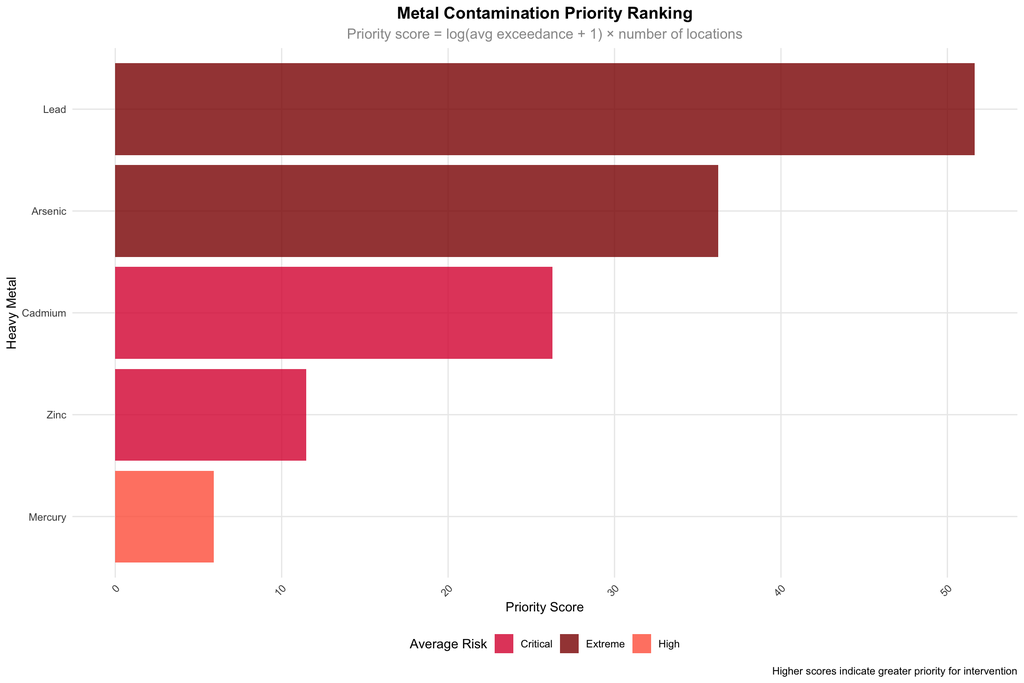

## Metal Priority Table

|  | Metal | Samples | Avg Exceedance | Max Exceedance | Critical/Extreme Cases | Avg Risk | Priority Score |
| --- | --- | --- | --- | --- | --- | --- | --- |
| 1 | Lead | 513 | 1685.6 | 231150 | 503 | Extreme | 51.63 |
| 2 | Arsenic | 431 | 182.6 | 10400 | 419 | Extreme | 36.22 |
| 3 | Cadmium | 432 | 42.8 | 450 | 359 | Critical | 26.27 |
| 4 | Zinc | 35 | 26.2 | 78 | 22 | Critical | 11.48 |
| 5 | Mercury | 35 | 4.5 | 26 | 4 | High | 5.92 |

# Geographic Hotspot Analysis

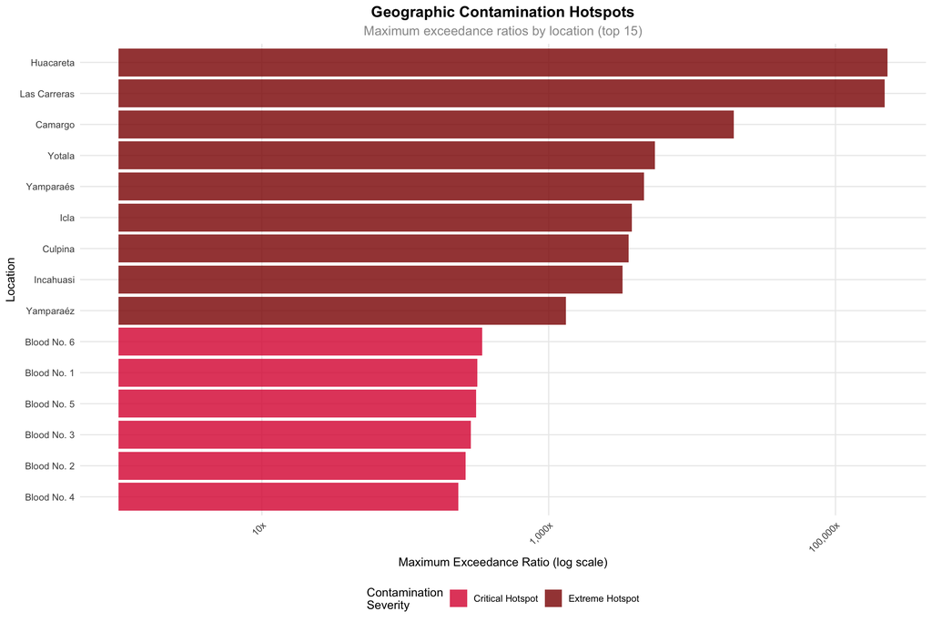

# Standards Comparison

## Regulatory Framework

This analysis compares contamination levels against multiple regulatory standards:

|  | Metal | WHO Water (mg/L) | Codex Food (mg/kg) | EPA Soil (mg/kg) | CDC Blood (µg/dL) |
| --- | --- | --- | --- | --- | --- |
| 1 | Lead | 0.01 | 0.3 | 70 | 5 |
| 2 | Arsenic | 0.01 | 0.2 | 39 |  |
| 3 | Cadmium | 0.003 | 0.1 | 10 |  |
| 4 | Mercury | 0.006 | 0.5 |  |  |
| 5 | Copper | 2 |  |  |  |
| 6 | Iron | 3 |  |  |  |
| 7 | Zinc | 3 |  |  |  |
| 8 | Nickel | 0.07 |  |  |  |
| 9 | Chromium | 0.05 |  |  |  |
| 10 | Aluminum | 0.2 |  |  |  |

[output cut: 1 more lines]

# Environmental Impact Assessment

## Multi-Matrix Contamination

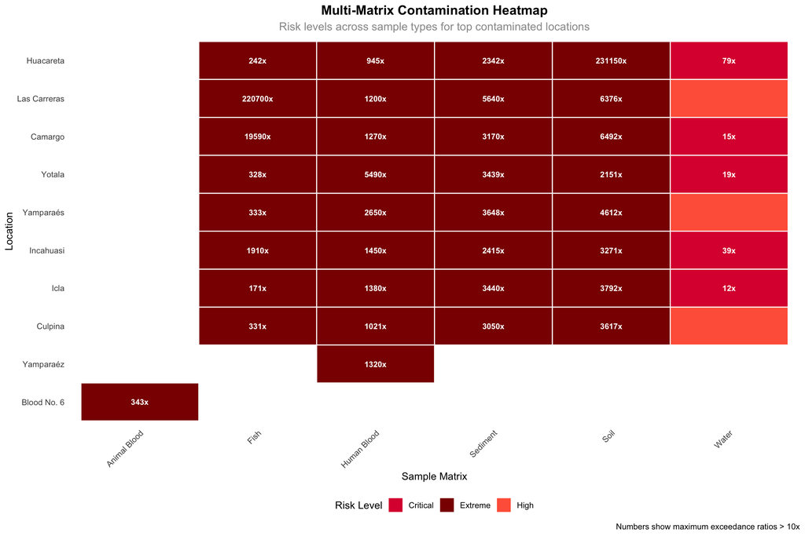

# Conclusions and Recommendations

## Key Findings Summary

**🚨 Critical Environmental Crisis**

The 2006 baseline assessment reveals a **catastrophic contamination scenario** in the Pilcomayo River Basin:

1. **Systemic Contamination**: 90.4% of samples exceed WHO standards
2. **Extreme Lead Pollution**: Up to 231,150x WHO limits in soil
3. **Multi-Matrix Impact**: Contamination across water, soil, sediment, food, and biological systems
4. **Geographic Hotspots**: Las Carreras, Huacareta, Camargo, and Yotala show extreme contamination
5. **Human Health Crisis**: Elevated lead levels in human blood samples

## Priority Action Areas

| Priority | Action | Timeline | Estimated_Cost |
| --- | --- | --- | --- |
| Immediate | Emergency remediation at Huacareta and Las Carreras | 0-3 months | High |
| Immediate | Public health intervention in affected communities | 0-6 months | Medium |
| Short-term | Source control and waste management improvements | 6-12 months | High |
| Medium-term | Comprehensive environmental restoration program | 1-3 years | Very High |
| Long-term | Long-term monitoring and health surveillance | Ongoing | Medium |

## Regulatory Compliance

**Legal Framework Violations:** - Multiple violations of WHO drinking water guidelines - Exceedances of EPA soil contamination limits - Food safety concerns under Codex Alimentarius standards - Public health risks exceeding CDC blood lead reference values

## Future Research Priorities

1. **Source Attribution**: Identify specific contamination sources
2. **Temporal Trends**: Compare with 2011 Cerro Rico and 2024 TNC data
3. **Bioaccumulation Studies**: Assess food chain contamination
4. **Health Impact Assessment**: Comprehensive epidemiological study
5. **Remediation Technology**: Evaluate treatment options

*This report establishes the 2006 baseline for the River Remedy project’s multi-temporal analysis of Pilcomayo Basin contamination. The findings underscore the urgent need for comprehensive environmental intervention and long-term monitoring.*

**Data Sources:** - Fundación I.T.A. (2006). Informe Final: Muestreo de aguas, suelos, vegetales, sangre humana y animales, peces y sedimentos en puntos seleccionados de la Cuenca del Río Pilcomayo - WHO Guidelines for Drinking-water Quality (2017) - Codex Alimentarius CXS 193-1995 Rev. 2018 - CDC Blood Lead Reference Value (2021)